# Appendix S6: Realistic simulation and comparison of three approaches to fitting biphasic growth models

Kyle L Wilson The University of Calgary

October 5, 2017

This appendix is in support of Wilson *et al.* (2017). The citation style language (csl) used herein is the methods-in-ecology-and-evolution.csl file which can be downloaded from https://github.com/citation-style-language/styles/blob/master/methods-in-ecology-and-evolution.csl and placed in the same directory as this .rmd file.

## Summary description of objectives:

where $theta_i$ is one of the estimated parameters (e.g., $h$) for a given approach and set of starting values.

## Global functions

We will first define some global functions that will be used below.

```r
Corner_text <- function(text, location="topright") #function to write text to the corner of plots
{
  legend(location,legend=text, bty ="n", pch=NA)
}

panel.cor <- function(x, y, digits = 2, prefix = "", cex.cor, ...) #function to change size of text in the pairs plots to match the size of the correlation
{
  usr <- par("usr"); on.exit(par(usr))
  par(usr = c(0, 1, 0, 1))
  r <- abs(cor(x, y))
  txt <- format(c(r, 0.123456789), digits = digits)[1]
  txt <- paste0(prefix, txt)
  if(missing(cex.cor)) cex.cor <- 0.8/strwidth(txt)
  text(0.5, 0.5, txt, cex = cex.cor * r)
}

biphasicPlot <- function(h=h,g=g,t1=t1,Tmat=Tmat) #function to return the biphasic growth trajectory for a given set of parameters
{
  LT_ages <- ages
  juv <- h*(LT_ages-t1)
  adult <- (3*h/g)*(1-exp(-(log(1+g/3))*(LT_ages-(Tmat+log(1-g*(Tmat-t1)/3)/log(1+g/3)))))
  pred <- ifelse(LT_ages<=Tmat,juv,adult)
  return(pred)
}
```

First, we must load the required libraries and specify the simulated ‘true’ life history parameter values. We will set the coefficient of variation in length-at-age at 20%, a little larger than typically observed for fisheries data (see review in Lorenzen (2016)).

```r
library(boot)  # use install.packages('boot') if package isn't already installed
library(runjags)  #load, install, or require the 'runjags' library
library(rjags)
library(stats4)  #load the 'stats4' library
library(coda)

ages <- 1:30  #create an integer sequence of ages

Tmat <- 4  # age of maturity
h <- 50  # somatic growth in millimeters per year
t1 <- -0.2  #age when size=0 for the juvenile phase
M <- 0.25  #Natural mortality for the population
g <- 1.18 * (1 - exp(-M))  # proportion of energy in adult phase allocated to reproduction per year
cv <- 0.2  # coefficient of variation in size-at-age
linf = 3 * h/g  ## von Bertalanffy asymptotic length (mm)
vbk = log(1 + g/3)  ## Brody growth coefficient (per yr)
t0 = Tmat + suppressWarnings(log(1 - (g * (Tmat - t1)/3)))/log(1 + g/3)  ## von Bertalanffy hypothetical age at length 0 (yr)

Nfish <- 100  # how many fish in total do you have?

lena_phase1 <- h * (ages - t1)  # length-at-age for phase 1
lena_phase2 <- linf * (1 - exp(-vbk * (ages - t0)))  # length-at-age for phase 2
biphasic <- ifelse(ages <= Tmat, lena_phase1, lena_phase2)  #if-else statement for which phase a fish is allocating surplus energy
```

Next, we will calculate survivorship-at-age $l_a$, which is the expected discrete annual survival based on constant mortality $M$ calculated from a reference age, for the 30 ages (length of the vector `ages`). In this case $l_1=1$ and for every age $a>=2$:

$$l_a= l_{a-1}*e^{-M}$$
.

We also induce selectivity-at-age $s_a$ in the sampling process with the equation
$$s_a=1/(1+e^{slope*(a-a_\text{50})}$$
.

```r
surv <- rep(NA, length(ages))  # create an empty vector
surv[1] <- 1
for (i in 2:max(ages)) {
    surv[i] <- surv[i - 1] * exp(-M)
}  #survivorship from discrte annual survival
gearA50 <- Tmat  # induce a gear selectivity that inflects at A50
gearSlope <- -0.4  # whats the slope of selectivity
select <- 1/(1 + exp(gearSlope * (ages - gearA50)))  # the average selectivity curve
```

Next, we will generate data using a random normal distribution (realized parameter values and model fit quality will change due to randomness) using the `rnorm()` function. Sample sizes expected for each age are realistic for fisheries data and are determined using a function of gear selectivity and survivorship arising from a multinomial process using the `rmultinom()` function. The expected probability of sampling fish of a particular age class will be $l_a*s_a$. Alternatively, we could have read in our data with, for example, a .csv file replacing the `Data` object.

```r
SampSize <- 10000
set.seed(2016)
maxSamp <- as.vector(rmultinom(1, prob = surv * select, size = SampSize))  # whats the maximum number of observable samples for an age group in a population?
mean.samp <- as.data.frame(cbind(biphasic, maxSamp))  #make matrix of mean lengths-at-age and sample sizes
mlen <- rep(mean.samp[, 1], mean.samp[, 2])  #repeat each mean 'sample size' number of times
ageData <- rep(ages, mean.samp[, 2])  #repeat each age 'sample size' number of times
lengths <- sapply(mlen, function(x) rnorm(1, mean = x, sd = x * cv))  #generate random normal length data using means & cv error
Data <- as.data.frame(cbind(ageData, lengths))  #bind vectors into age and length matrix, covert to data frame
colnames(Data) <- c("Age", "Size")  # re-name the columns
Data <- Data[sample(nrow(Data), size = Nfish, replace = F), ]  #draw a random sample from the population -- total sample size can be adjusted with the Nfish parameter
```

Here is how our data look currently with the expected samples-at-age from the multinomial process.

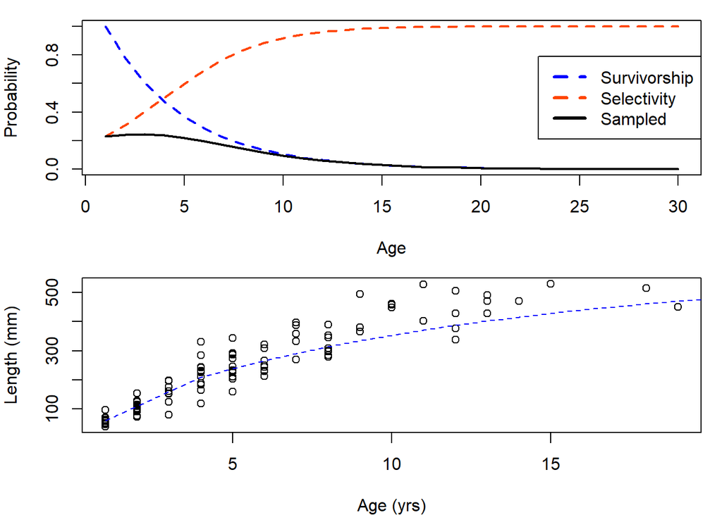

```r
layout(matrix(c(1, 2), nrow = 2, ncol = 1))
par(mar = c(4, 4, 1, 1))
plot(ages, surv, ylab = "Probability", xlab = "Age", type = "l", lty = 2, col = "blue",
    lwd = 2)
lines(ages, select, lty = 2, col = "orangered", lwd = 2)
lines(ages, surv * select, lty = 1, lwd = 2)
legend("right", c("Survivorship", "Selectivity", "Sampled"), lty = c(2, 2, 1),
    col = c("blue", "orangered", "black"), lwd = 3)

plot(Data$Age, Data$Size, ylab = "Length (mm)", xlab = "Age (yrs)")  ## plot length-at-age
lines(ages, biphasic, lty = 2, col = "blue")
```

## Approach 1 - Penalized likelihood

The next step is to duplicate what we did in Appendix S3, where we specify the likelihood function. We estimate five parameters: $T$, $h$, $t_1$, $g$, and the $cv$ in length-at-age. We provide conversions for the von Bertalanffy (mature) growth parameters, and we use an if-else statement to differentiate between immature and mature growth. Finally, we use a penalized likelihood to help ensure that estimates of $g$ do not venture outside of analytical bounds (see Lester, Shuter & Abrams (2004)).

```r
nll <- function(theta) {
    h <- theta[1]
    t1 <- theta[2]
    g <- inv.logit(theta[3])
    size.cv <- theta[4]
    T_pred <- theta[5]
    ######################################################## make conversions to phase 2 VBGF parameters #########
    linf <- 3 * h/g
    vbk <- log(1 + g/3)
    t0 <- Tmat + log(1 - g * (T_pred - t1)/3)/log(1 + g/3)

    ######################################################## Make predictions to the data ########################

    pred1 <- h * (Data$Age - t1)  #predicted length for phase 1
    pred2 <- linf * (1 - exp(-vbk * (Data$Age - t0)))  #predicted length for phase 2
    pred_all <- ifelse(Data$Age <= T_pred, pred1, pred2)  #discontinuous maturity breakpoint
    ll <- dnorm(Data$Size, mean = pred_all, sd = pred_all * size.cv, log = TRUE)  #normal likelihood with constant cv across ages
    if ((g < 0) | (g > (3/(T_pred - t1)))) {
        nll <- 1e+06  # penalized likelihood when g goes past bounds given in Lester et al. 2004; g must be > 0 OR < 3/(T-t1)
    } else {
        nll <- -sum(ll)  # return the negative log-likelihood
    }
    return(nll)
}
```

### Optimization and visualization of results

To fit the model, we first provide and compile starting values for each parameter. We then use the `optim()` function to optimize the likelihood function for our list of parameters.

In this case, we use three different starting value vectors to evaluate the sensitivity of each approach to starting values.

```r
h.hat <- 35  # the following are initial parameter estimates
t1.hat <- -3
g.hat <- logit(0.07)
cv.hat <- 0.1
T.hat <- 11.5
theta <- c(h.hat, t1.hat, g.hat, cv.hat, T.hat)  # initial parameter estimates vector 1
theta2 <- c(h.hat * 1.5, t1.hat * 0.5, g.hat * 2, cv.hat * 1.5, T.hat * 0.75)  # initial parameter estimates vector 3
theta3 <- c(h.hat * 2, t1.hat * 0.2, g.hat * 3, cv.hat * 2, T.hat * 0.5)  # initial parameter estimates vector 2

par.true <- c(h, t1, g, cv, Tmat)

fit <- optim(theta, nll, method = "BFGS", control = list(fnscale = 1, maxit = 1e+05,
    reltol = 1e-10), hessian = TRUE)
fit2 <- optim(theta2, nll, method = "BFGS", control = list(fnscale = 1, maxit = 1e+05,
    reltol = 1e-10), hessian = TRUE)
fit3 <- optim(theta3, nll, method = "BFGS", control = list(fnscale = 1, maxit = 1e+05,
    reltol = 1e-10), hessian = TRUE)
```

We then create a function that stores the maximum likelihood estimates and 95% asymptotically normal CI from a Hessian matrix.

```r
optimFits <- function(x) {
    par.hats <- x$par
    par.hats[3] <- inv.logit(par.hats[3])  # return the g parameter in normal space from logit
    fisher_info <- solve(x$hessian)  #take the inverse of the hessian to get the var-covar matrix
    prop_sigma <- sqrt(diag(fisher_info))  #square-root the var-covar matrix to get sigmas (i.e., standard errors)
    SE.par <- prop_sigma
    UI <- par.hats + 1.96 * SE.par
    LI <- par.hats - 1.96 * SE.par
    perBias <- ((par.hats - par.true)/par.true) * 100
    LIBias <- ((LI - par.true)/par.true) * 100
    UIBias <- ((UI - par.true)/par.true) * 100
    return(list(mn.95 = rbind(par.hats, UI, LI), bias = rbind(perBias, UIBias,
        LIBias)))
}
m1 <- optimFits(fit)
m2 <- optimFits(fit2)
m3 <- optimFits(fit3)

approach1 <- list(m1, m2, m3)  #Store the results of approach 1 for plotting later
```

## Approach 2 - Likelihood profiling

In this case, we will use the profile likelihood approach ((Honsey, Staples & Venturelli 2016)) See Appendix S4 for details.

```r
Biphas.Lik.MA = function(parms) {
    # list parameters
    h1 <- parms[1]
    b0 <- parms[2]
    g <- inv.logit(parms[3])
    cv <- parms[4]
    age.i <- Data$Age[Data$Age <= mat.age]  ## define immature ages
    len.i <- Data$Size[Data$Age <= mat.age]  ## define immature lengths
    age.m <- Data$Age[Data$Age > mat.age]  ## define mature ages
    len.m <- Data$Size[Data$Age > mat.age]  ## define mature lengths

    ## Lester model equations
    t1 <- -b0/h1
    Linf <- 3 * h1/g
    k <- log(1 + g/3)
    t0 <- mat.age + suppressWarnings(log(1 - (g * (mat.age - t1)/3)))/log(1 +
        g/3)
    mn.i <- b0 + h1 * age.i
    mn.m <- Linf * (1 - exp(-k * (age.m - t0)))

    ## Likelihoods
    b0.lik <- dnorm(b0, mean = b0est, sd = 25, log = T)  #optional (also, distribution can be adjusted if needed)
    h1.lik <- dnorm(h1, mean = h1est, sd = 5, log = T)  #optional (also, distribution can be adjusted if needed)
    L.i <- dnorm(len.i, mean = mn.i, sd = mn.i * cv, log = T)
    L.m <- dnorm(len.m, mean = mn.m, sd = mn.m * cv, log = T)
    ll <- sum(c(L.i, L.m))  #without likelihood priors
    jll <- sum(c(L.i, L.m, b0.lik, h1.lik))  # with likelihood priors
    return(ll)
}
```

Below, we specify the three starting value vectors.

```r
immdata <- Data[which(Data$Age <= (min(Data$Age) + 3)), ]  #choose data within first four ages -- number of ages can be changed
immout <- lm(Size ~ Age, data = immdata)  #linear regression on 'immature' data -- change formulation as needed to match your data column names
b0est <- immout$coefficients[[1]]  # store intercept estimate, used for prior likelihood
h1est <- immout$coefficients[[2]]  # store slope estimate, used for prior likelihood
t1est <- -b0est/h1est
parms1 <- theta[-5]  #compile parameters
parms2 <- theta2[-5]  # initial parameter estimates
parms3 <- theta3[-5]  # initial parameter estimates
parms <- rbind(parms1, parms2, parms3)
parms[, 2] <- -parms[, 1] * parms[, 2]
```

Next, we make empty dataframes for storing the parameter estimates, and we generate a sequence of potential age-at-maturity values for profiling.

```r
Mat.age <- seq(2, max(ages), by = 0.025)  #  range of mat.age values for profile likelihood calculation -- adjust as needed
lik <- b0.mat <- h.mat <- g.mat <- cv.mat <- rep(NA, length(Mat.age))  # create empty vectors for parameters
mat.age.df <- cbind(Mat.age, lik, h.mat, b0.mat, g.mat, cv.mat)  # create matrix for storing parameter estimates

mat.age.Lik <- array(mat.age.df, dim = c(dim(mat.age.df), 3))
```

We then optimize the likelihood function for each potential age-at-maturity value and store both parameter estimates and full-model likelihoods.

```r
for(i in 1:3) #loop over 3 times for different starting vectors
{
  for(j in 1:length(Mat.age))
  {
    mat.age = Mat.age[j] # fix age-at-maturity at a given value
    L.out = try(optim(par=parms[i,],fn=Biphas.Lik.MA,
                      control=list(fnscale=-1,reltol=1e-8)), silent=T) # optimize likelihood function
    check<-is.numeric(L.out[[1]]) # check to see if model converged

    ## store values only if model converged
    if (check[[1]] == "TRUE"){

      #Store parameter values (back-transform g)
      mat.age.Lik[j,2,i] <- L.out$value
      mat.age.Lik[j,3,i] <- L.out$par[[1]]
      mat.age.Lik[j,4,i] <- L.out$par[[2]]
      mat.age.Lik[j,5,i] <- inv.logit(L.out$par[[3]])
      mat.age.Lik[j,6,i] <- L.out$par[[4]]
    }
  }
  XX <- as.data.frame(mat.age.Lik[,,i])
  colnames(XX) <- c("Mat.age","lik","h.mat","b0.mat","g.mat","cv.mat")
  assign(paste("mat.age.df",i,sep=""),XX)
}
```

Next, we find the maximum likelihood estimate for $T$ (and the remaining parameters) from the profiling procedure.

```r
findMLE <- function(x) {
    x1 <- x[which(x$lik != "NA"), ]  #remove failed runs
    mle <- max(x1$lik, na.rm = TRUE)  ## find maximum likelihood
    MLE <- x1[which(x1$lik == mle), ]  ## maximum likelihood estimates for all parameters
    ## Confidence interval in terms of chi-squared (~ 95% CI)
    ndx1 = which(x1$lik > (mle - 1.92))  # change '1.92' to 0.228 for 50% CI, 1.36 for 90% CI
    CI = x1[ndx1, -2]
    return(list(data = x1, best.est = MLE, mle = mle, CI95 = CI))  ## print maximum likelihood estimates
}

MLE1 <- findMLE(mat.age.df1)
MLE2 <- findMLE(mat.age.df2)
MLE3 <- findMLE(mat.age.df3)

approach2 <- list(MLE1, MLE2, MLE3)  # Store the results of approach 2 for plotting later
```

If desired, one can calculate confidence intervals and plot the biphasic growth curves onto the data.

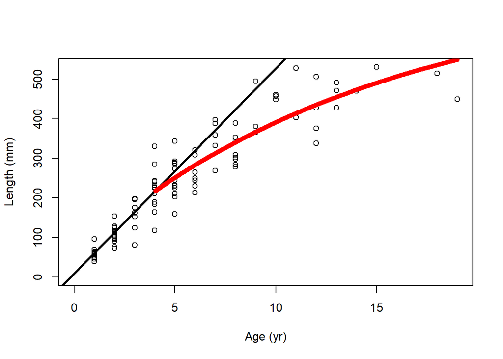

```r
rlike1 <- exp(MLE1$data$lik - MLE1$mle)
rlike2 <- exp(MLE2$data$lik - MLE2$mle)
rlike3 <- exp(MLE3$data$lik - MLE3$mle)

## Plot biphasic growth curves onto data
plot(Size ~ Age, data = Data, xlab = "Age (yr)", ylab = "Length (mm)", xlim = c(0,
    max(Age)), ylim = c(0, max(Size)))
g. = MLE1$best.est[[5]]
h1. = MLE1$best.est[[3]]
mT = MLE1$best.est[[1]]
b0. = MLE1$best.est[[4]]
t1. <- -b0./h1.
Linf. = 3 * h1./g.
k. = log(1 + g./3)
t0. = mT + log(1 - (g. * (mT - t1.)/3))/log(1 + g./3)
abline(b0., h1., lwd = 3)
matX = seq(mT, max(Data$Age), length.out = 25)
matY = Linf. * (1 - exp(-k. * (matX - t0.)))
lines(matX, matY, col = "red", type = "l", lwd = 6, lty = 1)
```

## Approach 3 - Bayesican MCMC

### Bayesian estimation

The following model code is written in the JAGS language (Plummer 2017). The model loops through each data point and determines the contribution of the predicted length for each fish to the posterior, which is the sum of the log-likelihood and the log-prior. The predicted growth follows the analytical model from the equations in Lester, Shuter & Abrams (2004). There is an if-else statement that determines if the predicted length-at-age of data point i comes from the juvenile phase or the adult phase. Modifications to this code require JAGS syntax and not R syntax.

```r
model <- "model {

## likelihood

#loop through all data points
for(i in 1:Nfish) {
size[i] ~ dnorm(pred[i],1/(pred[i]*size.cv)^2)T(0,) # observed length-at-age should be normally distributed around predictions

juv[i] <- h*(age[i]-t1) # predicted growth for fish i for the juvenile phase

adult[i] <- (3*h/g)*(1-exp(-(log(1+g/3))*(age[i]-(Tmat+log(1-g*(Tmat-t1)/3)/log(1+g/3))))) # predicted growth for fish [i] for the adult phase

pred[i] <- ifelse(age[i]<=Tmat,juv[i],adult[i]) # does the age of fish i exceed the maturity predicted for its population?

} # end the calculation of the likelihood



## prior distributions

Tmat ~ dunif(0,max(age))
h ~ dnorm(30,1e-3)T(0,)
t1 ~ dnorm(0,1)
g ~ dnorm(0.1,0.001)T(0,3/(Tmat-t1))
size.cv ~ dgamma(0.01,0.01)
}"
```

We then compile the data into a list for JAGS. In addition, we must provide starting values for each parameter within each chain. In this case, we use a random number generator to ‘jitter’ the starting values for each chain. We then compile the starting values for each chain into a list (in effect, creating a ‘list of lists’).

```r
dataPop <- Data
data <- list(Nfish = length(Data$Age), age = Data$Age, size = Data$Size)

inits1 <- list(h = theta[1], t1 = theta[2], g = inv.logit(theta[3]), Tmat = theta[5],
    size.cv = theta[4])  # initial values mirroring approaches 1 and 2 starting values

inits2 <- list(h = theta2[1], t1 = theta2[2], g = inv.logit(theta2[3]), Tmat = theta2[5],
    size.cv = theta2[4])

inits3 <- list(h = theta3[1], t1 = theta3[2], g = inv.logit(theta3[3]), Tmat = theta3[5],
    size.cv = theta3[4])

inits <- list(inits1, inits2, inits3)  # compile all initial values into one list
```

Our last step before fitting the model is to provide some parameters for the JAGS MCMC algorithm. We first create the stochastic nodes to be monitored. We then store values for the thinning rate, the length of the burn-in (or warm-up) period, and the length of the adaptation period. In this case, we specify these values based on the total number of posterior draws desired for each chain.

We use the `run.jags()` command (Denwood 2016) to fit the model, and we reference the JAGS parameters as specified above. We use the `rjags` method in this case – for larger datasets or more complicated (e.g., hierarchical) models, the `rjparallel` method may be preferred. Users may need to run `install.packages("rjags")` prior to running this portion of code.

```r
mon_names <- names(inits1)  # create the stochastic nodes to be monitored
Nsamp <- 1000  # how many posterior samples does each chain need to get, after thinning and burin-in and adaptation?
thin_rt <- 20  # needs a decent thinning rate
burnins <- 0.75 * round(Nsamp * thin_rt, 0)  # how long is the burnin, this bases it on the number of total posterior draws?
adaptin <- round(0.4 * burnins, 0)

a <- proc.time()
results <- run.jags(model = model, monitor = mon_names, data = data, n.chains = 3,
    method = "rjags", inits = inits, plots = F, silent.jag = F, modules = c("bugs",
        "glm", "dic"), sample = Nsamp, adapt = adaptin, burnin = burnins, thin = thin_rt,
    summarise = F)  # Call jags to run the model
## module glm loaded
## module dic loaded
## Compiling rjags model...
## Calling the simulation using the rjags method...
## Adapting the model for 6000 iterations...
## Burning in the model for 15000 iterations...
## Running the model for 20000 iterations...
## Simulation complete
## Finished running the simulation
b <- (proc.time() - a)
```

Next, we will call the summary of the model fit. We can also show some diagnostic plots that evaluate whether the posterior has converged on a stable mode using the package `coda()` (Plummer *et al.* 2006).

We next show a pairs plot to see how correlated the parameters are during the MCMC estimation. One may wish to use a multivariate normal distribution in the JAGS model above to allow for the correlations to be incorporated into the MCMC sampling (Helser & Lai 2004).

```r
sum_results <- summary(results)
## Calculating summary statistics...
## Calculating the Gelman-Rubin statistic for 5 variables....
sum_results
```

```
##            Lower95     Median     Upper95       Mean         SD       Mode
## h       41.4646836 49.3106880 57.81588571 49.7661423 4.36232020 49.2761956
## t1      -0.5535540 -0.2583426  0.01613255 -0.2631185 0.14609852 -0.2420344
## g        0.1335616  0.2134546  0.30103322  0.2145708 0.04352655  0.2074849
## Tmat     2.1697070  4.7192489 10.01351461  5.1120007 1.85645543  4.4441446
## size.cv  0.1691741  0.1966198  0.22626641  0.1974413 0.01510957  0.1954942
##                MCerr MC%ofSD SSeff       AC.200     psrf
## h       0.1411876437     3.2   955  0.002774298 1.003564
## t1      0.0042461454     2.9  1184 -0.011431035 1.001313
## g       0.0010057233     2.3  1873 -0.011275664 1.000195
## Tmat    0.0502570199     2.7  1365  0.017755853 1.000366
## size.cv 0.0002857976     1.9  2795 -0.007222608 1.000591
```

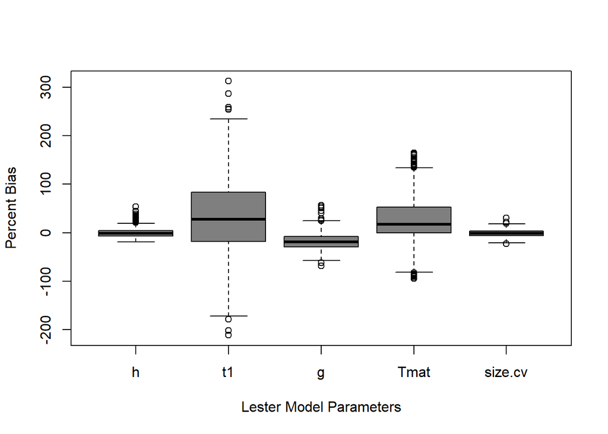

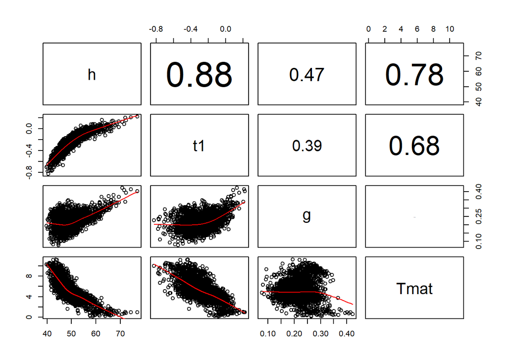

```r
TheRes <- as.mcmc.list(results, vars = mon_names)  # this is in the 'coda' package
TheRes1 <- as.matrix(TheRes[[1]])  ## results from starting point 1
TheRes2 <- as.matrix(TheRes[[2]])  ## results from starting point 2
TheRes3 <- as.matrix(TheRes[[3]])  ## results from starting point 3
approach3 <- list(TheRes1, TheRes2, TheRes3)
TheResTot <- as.matrix(TheRes)
BayesTruePar <- as.vector(c(h, t1, g, Tmat, cv))
bias1 <- t(apply(TheRes1, 1, FUN = function(x) {
    (x - BayesTruePar)/BayesTruePar * 100
}))
bias2 <- t(apply(TheRes2, 1, FUN = function(x) {
    (x - BayesTruePar)/BayesTruePar * 100
}))
bias3 <- t(apply(TheRes3, 1, FUN = function(x) {
    (x - BayesTruePar)/BayesTruePar * 100
}))
boxplot(bias1, ylab = "Percent Bias", xlab = "Lester Model Parameters", col = "grey50")

pairs(TheResTot[, -5], lower.panel = panel.smooth, upper.panel = panel.cor)  # look at the correlations between parameters
```

### Posterior predictive check

Next, we conduct a posterior predictive check (Gelman *et al.* (2013)). We simulate replicated data from our fitted JAGS model (with associated uncertainty for each estimated parameter from the model) and compare the distribution of our new *simulated* data to the *observed* data. In this case, the *observed* data is our original simulated data used in the model fitting in the `Data` object.

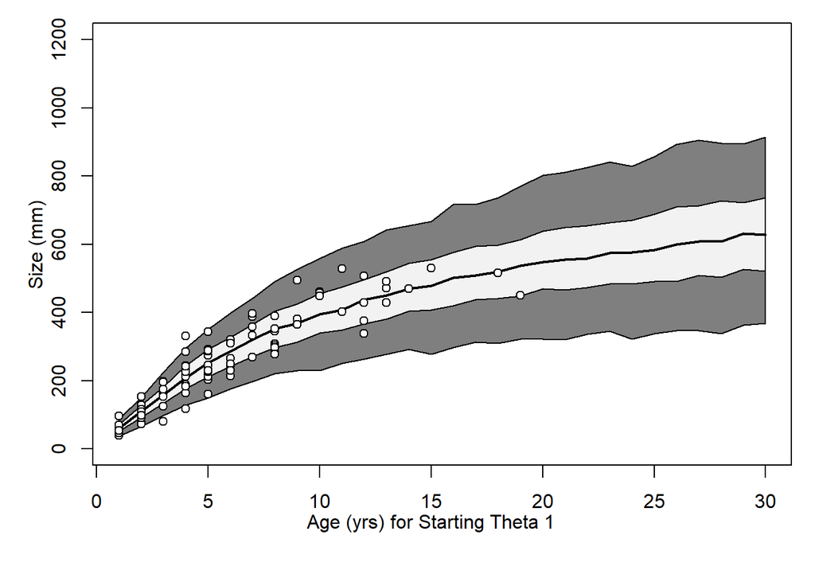

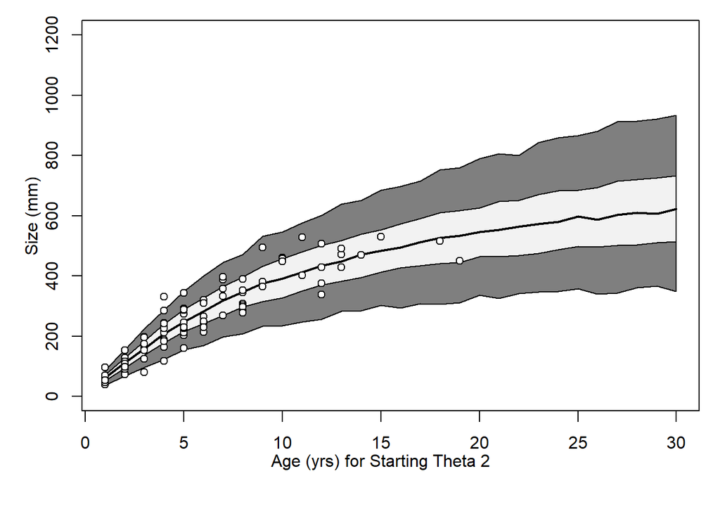

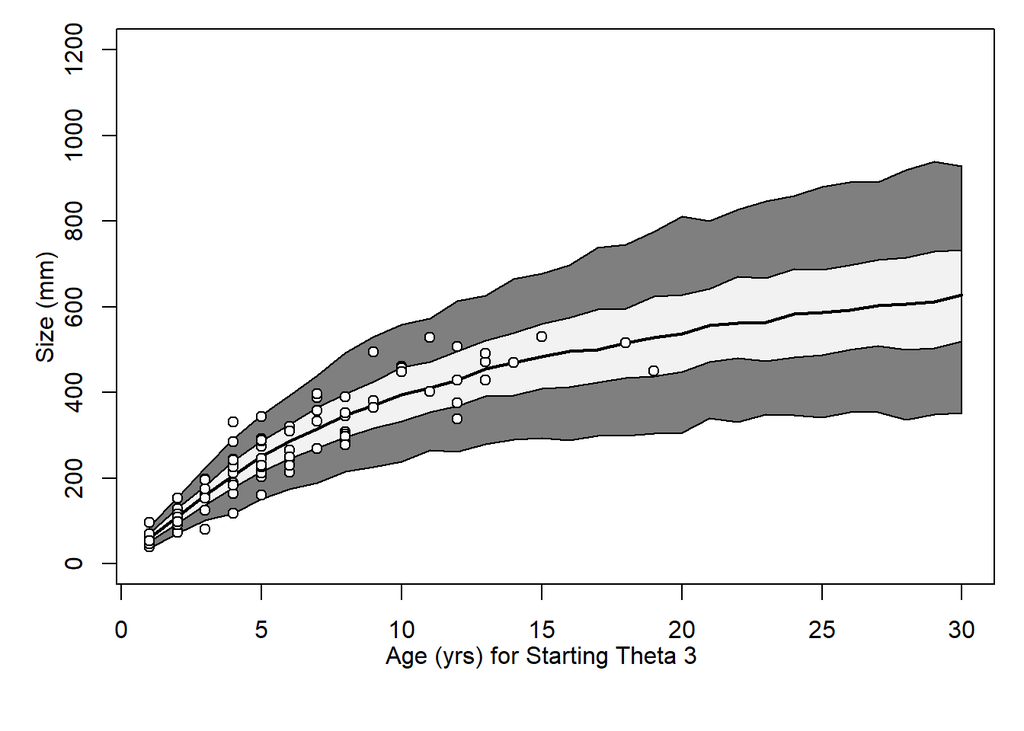

```r
age_vec <- c(ages, rev(ages))
# Above code creates an empty array to track size-at-age for population i
# for posterior draw j
par(mfrow = c(1, 1))
par(mar = c(5, 4, 1, 1))
layout(matrix(1, nrow = 1, ncol = 1))
for (i in 1:3) {
    TheRes <- approach3[[i]]
    post_pred <- matrix(NA, nrow = nrow(TheRes1), ncol = length(ages))
    for (j in 1:nrow(TheRes)) {
        h_j <- TheRes[j, match("h", colnames(TheRes))]
        g_j <- TheRes[j, match("g", colnames(TheRes))]
        Tmat_j <- TheRes[j, match("Tmat", colnames(TheRes))]
        t1_j <- TheRes[j, match("t1", colnames(TheRes))]
        cv_j <- TheRes[j, match("size.cv", colnames(TheRes))]

        linf <- 3 * h_j/g_j  # conversion for the VBGF L-infinity
        vbk <- log(1 + g_j/3)  # conversion for the VBGF parameter kappa
        t0 <- Tmat_j + log(1 - g_j * (Tmat_j - t1_j)/3)/log(1 + g_j/3)  #conversion for the VBGF parameter t0


        juv_j <- h_j * (ages - t1_j)
        adult_j <- linf * (1 - exp(-vbk * (ages - t0)))
        pred_j <- ifelse(ages <= Tmat_j, juv_j, adult_j)
        pred_j[pred_j < 0.001] <- 0.001
        post_pred[j, ] <- rnorm(length(ages), pred_j, pred_j * cv_j)
    }
    quants <- t(apply(post_pred[, ], 2, FUN = quantile, probs = c(0.025, 0.225,
        0.5, 0.775, 0.975)))
    plot(age_vec, c(quants[, 1], rev(quants[, 5])), type = "l", lwd = 2, col = NA,
        ylab = "", xlab = "", ylim = c(0, 1200))
    axis(1, at = median(c(0, max(ages))), paste("Age (yrs) for ", "Starting Theta ",
        i, sep = ""), tick = FALSE, line = 0.9)
    axis(2, at = 600, "Size (mm)", tick = FALSE, line = 1)
    polygon(age_vec, c(quants[, 1], rev(quants[, 5])), col = "grey50")
    polygon(age_vec, c(quants[, 2], rev(quants[, 4])), col = "grey95")
    lines(ages, quants[, 3], lwd = 2, col = "black")
    points(Data$Age, Data$Size, pch = 21, bg = "white")
}
```

The posterior predictive distribution covers most of the data, and we can see from graphical portrayal that there are no systematic discrepancies between the *observed* and *simulated* data. In general, we might conclude the model is valid and fits well to the data (one could conduct alternative Bayesian goodness-of-fit tests as well).

## Comparing the three different approaches using percent bias

First, we will store the approaches for percent bias calculations.

```r
m2.1 <- apply(approach2[[1]]$CI95,2,FUN=function(x){return(c(min(x),max(x)))}) ## find the 95% for approach 2 (profiling), start 1
m2.2 <- apply(approach2[[2]]$CI95,2,FUN=function(x){return(c(min(x),max(x)))}) ## find the 95% for approach 2 (profiling), start 2
m2.3 <- apply(approach2[[3]]$CI95,2,FUN=function(x){return(c(min(x),max(x)))}) ## find the 95% for approach 2 (profiling), start 3
CI <- rbind(approach2[[1]]$best.est[-2],m2.1, # storing for best estimates and 95% CI for profiling approach
            approach2[[2]]$best.est[-2],m2.2,
            approach2[[3]]$best.est[-2],m2.3)
bias2 <- apply(CI,1,function(x){(x-c(Tmat,h,-h*t1,g,cv))/c(Tmat,h,-h*t1,g,cv)*100}) # calculate percent bias for profiling approach
m3.1 <- apply(approach3[[1]],2,FUN=quantile,probs=c(0.025,0.5,0.975)) ## find the 95% for approach 3, start 1
m3.2 <- apply(approach3[[2]],2,FUN=quantile,probs=c(0.025,0.5,0.975)) ## find the 95% for approach 3, start 2
m3.3 <- apply(approach3[[3]],2,FUN=quantile,probs=c(0.025,0.5,0.975)) ## find the 95% for approach 3, start 3
bias3.1 <- apply(m3.1,1,function(x){(x-c(h,t1,g,Tmat,cv))/c(h,t1,g,Tmat,cv)*100}) ## calculate percent bias for Bayesian approach, starting point 1
bias3.2 <- apply(m3.2,1,function(x){(x-c(h,t1,g,Tmat,cv))/c(h,t1,g,Tmat,cv)*100}) ## calculate percent bias for Bayesian approach, starting point 2
bias3.3 <- apply(m3.3,1,function(x){(x-c(h,t1,g,Tmat,cv))/c(h,t1,g,Tmat,cv)*100}) ## calculate percent bias for Bayesian approach, starting point 3
```

Then we make plots for showing the bias for each parameter, each starting vector, and each approach.

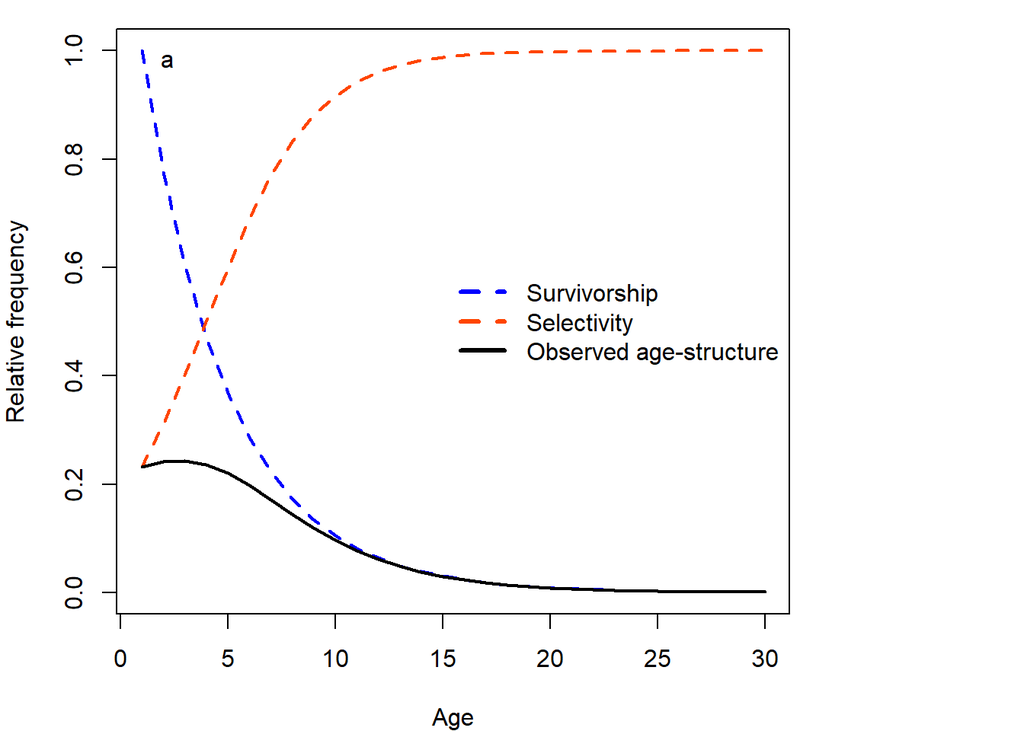

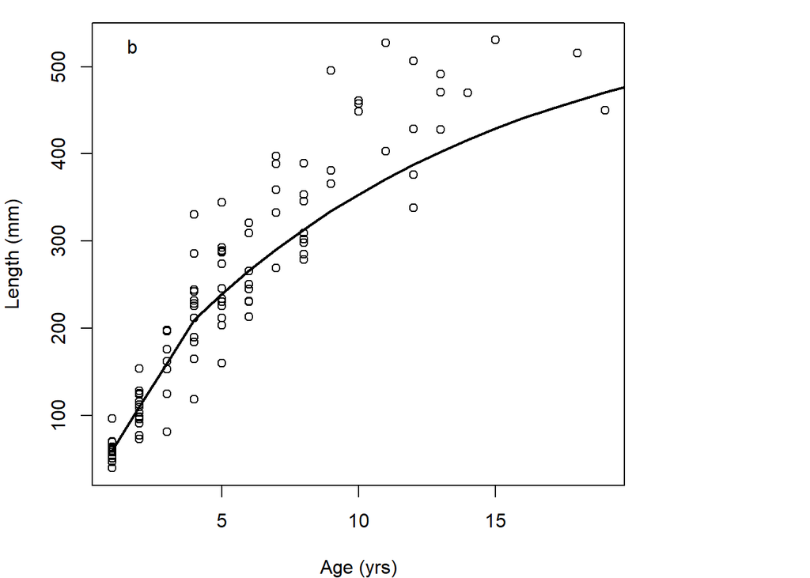

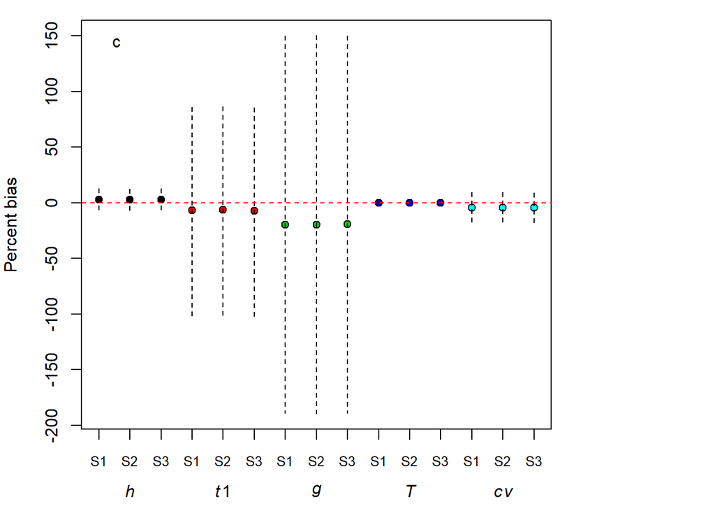

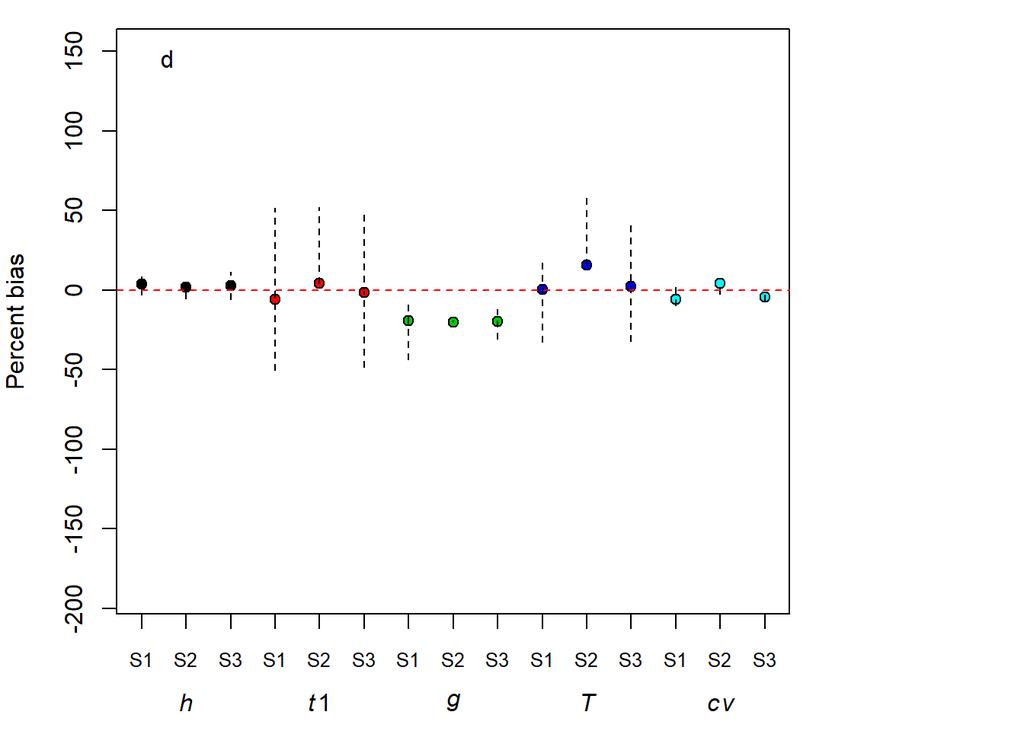

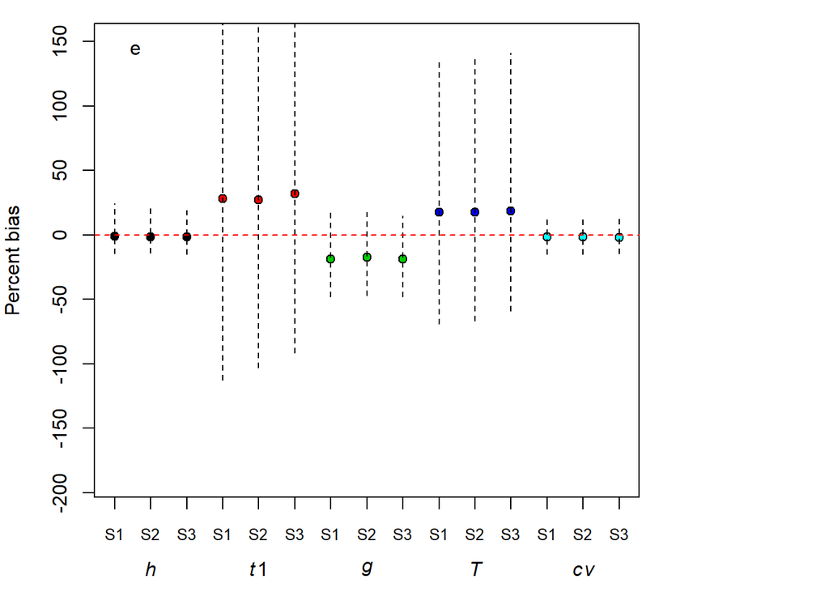

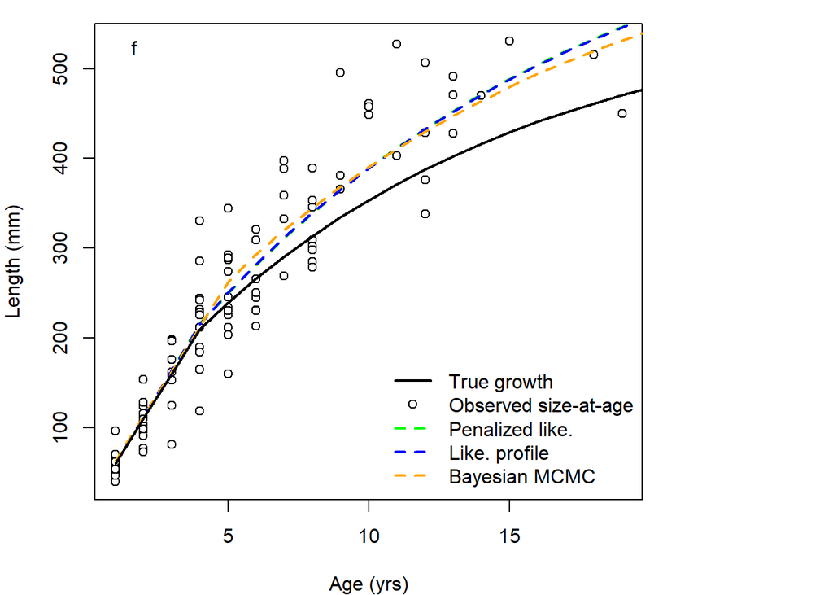

```r
# layout(matrix(1:6,nrow=3,ncol=2,byrow=T))
layout(matrix(1, nrow = 1, ncol = 1, byrow = T))
par(mar = c(4, 4, 1, 8))

plot(ages, surv, ylab = "Relative frequency", xlab = "Age", type = "l", lty = 2,
    col = "blue", lwd = 2)
lines(ages, select, lty = 2, col = "orangered", lwd = 2)
lines(ages, surv * select, lty = 1, lwd = 2)
legend("right", c("Survivorship", "Selectivity", "Observed age-structure"),
    lty = c(2, 2, 1), col = c("blue", "orangered", "black"), lwd = 3, bty = "n")
Corner_text("a", "topleft")

plot(Data$Age, Data$Size, ylab = "Length (mm)", xlab = "Age (yrs)")  ## plot length-at-age
lines(ages, biphasic, lty = 1, col = "black", lwd = 2)
Corner_text("b", "topleft")
ylimits <- range(c(approach1[[1]]$bias, approach1[[2]]$bias, approach1[[3]]$bias),
    na.rm = T)
plot(1:15, c(approach1[[1]]$bias[1, 1], approach1[[2]]$bias[1, 1], approach1[[3]]$bias[1,
    1], approach1[[1]]$bias[1, 2], approach1[[2]]$bias[1, 2], approach1[[3]]$bias[1,
    2], approach1[[1]]$bias[1, 3], approach1[[2]]$bias[1, 3], approach1[[3]]$bias[1,
    3], approach1[[1]]$bias[1, 5], approach1[[2]]$bias[1, 5], approach1[[3]]$bias[1,
    5], approach1[[1]]$bias[1, 4], approach1[[2]]$bias[1, 4], approach1[[3]]$bias[1,
    4]), ylab = "Percent bias", xlab = "", xaxt = "n", ylim = ylimits, pch = 21,
    bg = c(1, 1, 1, 2, 2, 2, 3, 3, 3, 4, 4, 4, 5, 5, 5))  # this is the bias at the maximum likelihood estimates for approach 1
segments(x0 = 1:15, x1 = 1:15, y0 = c(approach1[[1]]$bias[2, 1], approach1[[2]]$bias[2,
    1], approach1[[3]]$bias[2, 1], approach1[[1]]$bias[2, 2], approach1[[2]]$bias[2,
    2], approach1[[3]]$bias[2, 2], approach1[[1]]$bias[2, 3], approach1[[2]]$bias[2,
    3], approach1[[3]]$bias[2, 3], approach1[[1]]$bias[2, 5], approach1[[2]]$bias[2,
    5], approach1[[3]]$bias[2, 5], approach1[[1]]$bias[2, 4], approach1[[2]]$bias[2,
    4], approach1[[3]]$bias[2, 4]), y1 = c(approach1[[1]]$bias[3, 1], approach1[[2]]$bias[3,
    1], approach1[[3]]$bias[3, 1], approach1[[1]]$bias[3, 2], approach1[[2]]$bias[3,
    2], approach1[[3]]$bias[3, 2], approach1[[1]]$bias[3, 3], approach1[[2]]$bias[3,
    3], approach1[[3]]$bias[3, 3], approach1[[1]]$bias[3, 5], approach1[[2]]$bias[3,
    5], approach1[[3]]$bias[3, 5], approach1[[1]]$bias[3, 4], approach1[[2]]$bias[3,
    4], approach1[[3]]$bias[3, 4]), lty = 2)  # this is the bias at the 95% CI from Hessian matrix from approach 1
abline(h = 0, lty = 2, col = "red")
axis(1, at = c(2, 5, 8, 11, 14), expression(italic(h), italic(t1), italic(g),
    italic(T), italic(cv)), line = 1.5, tick = F)
axis(1, at = 1:15, rep(c("S1", "S2", "S3"), 5), line = 0, cex.axis = 0.8)
Corner_text("c", "topleft")

plot(1:15, c(bias2[2, c(1, 4, 7)], bias2[3, c(1, 4, 7)], bias2[4, c(1, 4, 7)],
    bias2[1, c(1, 4, 7)], bias2[5, c(1, 4, 7)]), pch = 21, bg = c(1, 1, 1, 2,
    2, 2, 3, 3, 3, 4, 4, 4, 5, 5, 5), ylab = "Percent bias", xlab = "", xaxt = "n",
    ylim = ylimits)  # this is the bias at the maximum likelihood estimates for profiling approach
segments(x0 = 1:15, x1 = 1:15, y0 = c(bias2[2, c(2, 5, 8)], bias2[3, c(2, 5,
    8)], bias2[4, c(2, 5, 8)], bias2[1, c(2, 5, 8)], bias2[5, c(2, 5, 8)]),
    y1 = c(bias2[2, c(3, 6, 9)], bias2[3, c(3, 6, 9)], bias2[4, c(3, 6, 9)],
        bias2[1, c(3, 6, 9)], bias2[5, c(3, 6, 9)]), lty = 2)  # segments draws the bias for the 95% CI from profiling approach
abline(h = 0, lty = 2, col = "red")
axis(1, at = c(2, 5, 8, 11, 14), expression(italic(h), italic(t1), italic(g),
    italic(T), italic(cv)), line = 1.5, tick = F)
axis(1, at = 1:15, rep(c("S1", "S2", "S3"), 5), line = 0, cex.axis = 0.8)
Corner_text("d", "topleft")

plot(1:15, c(bias3.1[1, 2], bias3.2[1, 2], bias3.3[1, 2], bias3.1[2, 2], bias3.2[2,
    2], bias3.3[2, 2], bias3.1[3, 2], bias3.2[3, 2], bias3.3[3, 2], bias3.1[4,
    2], bias3.2[4, 2], bias3.3[4, 2], bias3.1[5, 2], bias3.2[5, 2], bias3.3[5,
    2]), pch = 21, bg = c(1, 1, 1, 2, 2, 2, 3, 3, 3, 4, 4, 4, 5, 5, 5), ylab = "Percent bias",
    xlab = "", xaxt = "n", ylim = ylimits)  # this is the bias at the mean posterior for Bayesian approach
segments(x0 = 1:15, x1 = 1:15, y0 = c(bias3.1[1, 1], bias3.2[1, 1], bias3.3[1,
    1], bias3.1[2, 1], bias3.2[2, 1], bias3.3[2, 1], bias3.1[3, 1], bias3.2[3,
    1], bias3.3[3, 1], bias3.1[4, 1], bias3.2[4, 1], bias3.3[4, 1], bias3.1[5,
    1], bias3.2[5, 1], bias3.3[5, 1]), y1 = c(bias3.1[1, 3], bias3.2[1, 3],
    bias3.3[1, 3], bias3.1[2, 3], bias3.2[2, 3], bias3.3[2, 3], bias3.1[3, 3],
    bias3.2[3, 3], bias3.3[3, 3], bias3.1[4, 3], bias3.2[4, 3], bias3.3[4, 3],
    bias3.1[5, 3], bias3.2[5, 3], bias3.3[5, 3]), lty = 2)  # this is the bias at the 95% CI posterior for Bayesian approach
abline(h = 0, lty = 2, col = "red")
axis(1, at = c(2, 5, 8, 11, 14), expression(italic(h), italic(t1), italic(g),
    italic(T), italic(cv)), line = 1.5, tick = F)

axis(1, at = 1:15, rep(c("S1", "S2", "S3"), 5), line = 0, cex.axis = 0.8)
Corner_text("e", "topleft")
plot(Size ~ Age, data = Data, pch = 21, bg = "white", ylab = "Length (mm)",
    xlab = "Age (yrs)")  # draw the growth trajectories for each of the 3 approaches at starting vector 2 (i.e., theta2)
lines(ages, biphasicPlot(h = approach1[[3]]$mn.95[1, 1], g = approach1[[3]]$mn.95[1,
    3], t1 = approach1[[3]]$mn.95[1, 2], Tmat = approach1[[3]]$mn.95[1, 5]),
    lty = 2, lwd = 2, col = "green")
lines(ages, biphasicPlot(h = as.numeric(approach2[[3]]$best.est[3]), g = as.numeric(approach2[[3]]$best.est[5]),
    t1 = as.numeric(-approach2[[3]]$best.est[4]/approach2[[3]]$best.est[3]),
    Tmat = as.numeric(approach2[[3]]$best.est[1])), lty = 2, lwd = 2, col = "blue")
lines(ages, biphasicPlot(h = mean(TheResTot[, "h"]), g = mean(TheResTot[, "g"]),
    t1 = mean(TheResTot[, "t1"]), Tmat = mean(TheResTot[, "Tmat"])), lty = 2,
    lwd = 2, col = "orange")
lines(ages, biphasic, lty = 1, lwd = 2, col = "black")
legend("bottomright", c("True growth", "Observed size-at-age", "Penalized like.",
    "Like. profile", "Bayesian MCMC"), lty = c(1, NA, 2, 2, 2), lwd = c(2, 1,
    2, 2, 2), col = c(1, 1, "green", "blue", "orange"), pch = c(NA, 21, NA,
    NA, NA), pt.bg = c(NA, "white", NA, NA, NA), bty = "n", xpd = NA)
Corner_text("f", "topleft")
```

## References

Denwood, M.J. (2016). runjags: An R package providing interface utilities, model templates, parallel computing methods and additional distributions for MCMC models in JAGS. *Journal of Statistical Software*, **71**, 1–25.

Gelman, A., Carlin, J., Stern, H., Dunson, D., Vehtari, A. & Rubin, D. (2013). *Bayesian Data Analysis*, 3rd edn. Chapman and Hall/CRC Press.

Helser, T.E. & Lai, H.-L. (2004). A bayesian hierarchical meta-analysis of fish growth: With an example for north american largemouth bass, micropterus salmoides. *Ecological Modelling*, **178**, 399–416.

Honsey, A.E., Staples, D.F. & Venturelli, P.A. (2016). Accurate estimates of age at maturity from the growth trajectories of fishes and other ectotherms. *Ecological Applications*, **27**, 182–192.

Lester, N.P., Shuter, B.J. & Abrams, P.A. (2004). Interpreting the von bertalanffy model of somatic growth in fishes: The cost of reproduction. *Proceedings of the Royal Society B: Biological Sciences*, **271**, 1625–1631.

Lorenzen, K. (2016). Toward a new paradigm for growth modeling in fisheries stock assessments: Embracing plasticity and its consequences. *Fisheries Research*, **180**, 4–22.

Plummer, M. (2017). JAGS: A program for analysis of bayesian graphical models using gibbs sampling.

Plummer, M., Best, N., Cowles, K. & Vines, K. (2006). CODA: Convergence diagnosis and output analysis for mcmc. *R News*, **6**, 7–11.

Wilson, K.L., Honsey, A., Moe, B. & Venturelli, P. (2017). Growing the biphasic framework: techniques and recommendations for fitting emerging growth models. *Methods in Ecology and Evolution*, **In Review**.